# Case Study 3: Robust Variance Estimation for Longitudinal Data

Goh Gabriel

2025-06-05

# Introduction

Case studies 1 and 2 covered OLS versus GLS approaches and ANOVA / Multilevel modelling. In case study 3, we explore **robust variance estimation** as well as a brief return to GLS methods.

## Research Context

Working memory training programs promise to boost children’s cognitive abilities, but research results are mixed. Some studies show big improvements while others find no benefits at all.

It turns out that understanding intervention effects requires careful longitudinal analysis because these studies create complex data patterns. We have the typical dependency issues to contend with, but measurement variance often increases with age, participants may drop out over time, and intervention effects can vary by timing and individual characteristics. Further, in reality, within-subjects correlations often weaken over longer time gaps.

This case study examines data from a randomized controlled trial testing a working memory training program in school-age children tracked over 18 months. The research question is: **Does cognitive training produce sustained improvements in working memory performance compared to a control group?**

## Statistical Challenge

Mixed-effects (or multilevel) models make specific assumptions about correlation structures. When these assumptions are violated, even such sophisticated models can produce misleading standard errors and inflated Type I error rates.

How do we ensure our statistical conclusions remain valid when we’re uncertain about the true correlation structure of our longitudinal data? Robust variance estimators offer a methodological safety net. These “sandwich” estimators provide valid statistical inference even when correlation structures are misspecified.

## Key Learning Objectives

By the end of this analysis, you will:

- Understand why sophisticated longitudinal models can fail when correlation assumptions are violated
- Master robust variance estimators across different longitudinal scenarios
- Recognize the impact of methodological choices on intervention research conclusions
- Develop practical expertise in choosing between competing variance estimation approaches

# The Longitudinal Intervention Study

## Dataset Structure and Variables

```r
# Load the longitudinal dataset
study_data <- read.csv("data3.csv")

# Display basic structure
str(study_data)
```

```
## 'data.frame':    619 obs. of  12 variables:
##  $ child_id            : int  1 1 1 1 1 1 2 2 3 3 ...
##  $ timepoint           : int  1 2 3 4 5 6 1 2 1 2 ...
##  $ time_months         : int  0 3 6 9 12 18 0 3 0 3 ...
##  $ age_baseline        : num  11.7 11.7 11.7 11.7 11.7 ...
##  $ age_at_visit        : num  11.7 11.9 12.2 12.4 12.7 ...
##  $ iq                  : num  123 123 123 123 123 ...
##  $ ses                 : num  0.956 0.956 0.956 0.956 0.956 ...
##  $ intervention        : int  1 1 1 1 1 1 0 0 1 1 ...
##  $ post_intervention   : int  0 1 1 1 1 1 0 0 0 1 ...
##  $ working_memory_score: num  109 114 139 131 150 ...
##  $ time_centered       : int  -9 -6 -3 0 3 9 -9 -6 -9 -6 ...
##  $ time_scaled         : int  0 1 2 3 4 6 0 1 0 1 ...
```

The dataset contains **619 observations** from **120 children** assessed across different timepoints. Variable definitions:

- **`child_id`**: Unique identifier for each participant
- **`timepoint`**: Sequential visit number (1-6)
- **`time_months`**: Elapsed time since baseline (0, 3, 6, 9, 12, 18)
- **`time_centered`**: Time variable centered around intervention point
- **`time_scaled`**: Simplified time scale (0-6) for modeling
- **`age_baseline`**: Participant’s age at study entry
- **`age_at_visit`**: Participant’s age at each assessment
- **`iq`**: Intelligence quotient score at baseline
- **`ses`**: Socioeconomic status composite score
- **`intervention`**: Treatment group assignment (1 = intervention, 0 = control)
- **`post_intervention`**: Whether assessment occurred after intervention delivery
- **`working_memory_score`**: Primary cognitive outcome

# Examining the Data Pattern

Unlike cases 1 and 2, there is missing data in case study 3. Mixed effects models handle this seamlessly, and robust variance estimation techniques can also handle this when built around naive OLS estimators.

## Missingness and Retention Patterns

```r
# Check missingness pattern
missingness <- study_data %>%
  group_by(child_id, intervention) %>%
  summarise(
    n_visits = n(),
    last_visit = max(time_months),
    .groups = "drop"
  ) %>%
  group_by(intervention, n_visits) %>%
  summarise(n_children = n(), .groups = "drop")
```

### Missingness Pattern by Group

| Visits Completed | Control | Intervention |
| --- | --- | --- |
| 1 | 5 | 4 |
| 2 | 4 | 3 |
| 4 | 7 | 1 |
| 5 | 1 | 2 |
| 6 | 37 | 53 |
| 3 | 0 | 3 |

Most participants complete multiple visits, but there is considerable dropout.

## Descriptive Statistics Over Time

```r
# Descriptive statistics
descriptives <- study_data %>%
  group_by(time_months, intervention) %>%
  summarise(
    n = n(),
    mean_wm = mean(working_memory_score, na.rm = TRUE),
    sd_wm = sd(working_memory_score, na.rm = TRUE),
    .groups = "drop"
  )
```

### Working Memory Performance by Timepoint and Group

| Time (months) | Intervention | N | Mean WM | SD WM |
| --- | --- | --- | --- | --- |
| 0 | 0 | 54 | 99.72 | 10.93 |
| 0 | 1 | 66 | 97.14 | 11.72 |
| 3 | 0 | 49 | 101.94 | 10.73 |
| 3 | 1 | 62 | 108.37 | 12.10 |
| 6 | 0 | 45 | 102.09 | 11.22 |
| 6 | 1 | 59 | 110.81 | 12.96 |
| 9 | 0 | 45 | 104.31 | 12.62 |
| 9 | 1 | 56 | 110.68 | 13.07 |
| 12 | 0 | 38 | 108.12 | 15.48 |
| 12 | 1 | 55 | 113.89 | 13.63 |
| 18 | 0 | 37 | 108.51 | 15.36 |
| 18 | 1 | 53 | 115.11 | 14.20 |

The SD of the dependent variable increases over time, starting from about 10.93 (control) / 11.72 (intervention) to 15.36 (control) / 14.20 (intervention).

# Visualizing the Longitudinal Structure

## Individual Trajectories

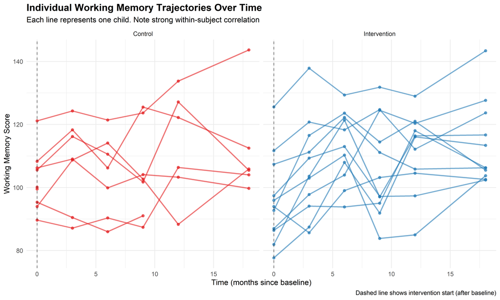

```r
# Plot individual trajectories showing within-subject correlation
set.seed(42)
sample_children <- sample(unique(study_data$child_id), 20)

trajectory_plot <- study_data %>%
  filter(child_id %in% sample_children) %>%
  ggplot(aes(x = time_months, y = working_memory_score, group = child_id)) +
  geom_line(aes(color = factor(intervention)), alpha = 0.6, size = 0.8) +
  geom_point(aes(color = factor(intervention)), alpha = 0.7, size = 1.5) +
  facet_wrap(~intervention, labeller = labeller(intervention = c("0" = "Control", "1" = "Intervention"))) +
  geom_vline(xintercept = 0, linetype = "dashed", alpha = 0.5) +
  scale_color_manual(values = c("0" = "#E31A1C", "1" = "#1F78B4")) +
  labs(
    title = "Individual Working Memory Trajectories Over Time",
    subtitle = "Each line represents one child. Note strong within-subject correlation",
    x = "Time (months since baseline)",
    y = "Working Memory Score",
    color = "Group",
    caption = "Dashed line shows intervention start (after baseline)"
  ) +
  theme_minimal() +
  theme(
    plot.title = element_text(size = 14, face = "bold"),
    legend.position = "none"
  )

print(trajectory_plot)
```

The trajectories demonstrate strong within-subject correlation that violates independence assumptions of standard regression.

## Mean Trajectories and Group Differences

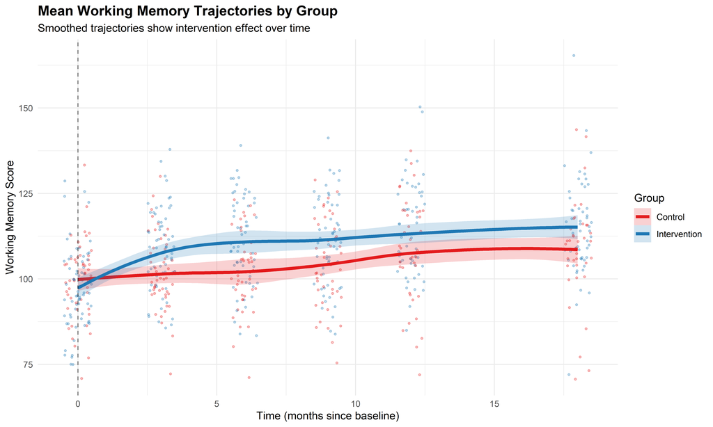

```r
# Mean trajectories with confidence bands
mean_trajectory_plot <- study_data %>%
  ggplot(aes(x = time_months, y = working_memory_score, color = factor(intervention), fill = factor(intervention))) +
  geom_point(alpha = 0.3, size = 0.8, position = position_jitter(width = 0.5)) +
  geom_smooth(method = "loess", size = 1.5, alpha = 0.2) +
  geom_vline(xintercept = 0, linetype = "dashed", alpha = 0.5) +
  scale_color_manual(values = c("0" = "#E31A1C", "1" = "#1F78B4"),
                     labels = c("Control", "Intervention")) +
  scale_fill_manual(values = c("0" = "#E31A1C", "1" = "#1F78B4"),
                    labels = c("Control", "Intervention")) +
  labs(
    title = "Mean Working Memory Trajectories by Group",
    subtitle = "Smoothed trajectories show intervention effect over time",
    x = "Time (months since baseline)",
    y = "Working Memory Score",
    color = "Group",
    fill = "Group"
  ) +
  theme_minimal() +
  theme(plot.title = element_text(size = 14, face = "bold"))

print(mean_trajectory_plot)
```

## Residual Analysis: Evidence of Heteroskedasticity

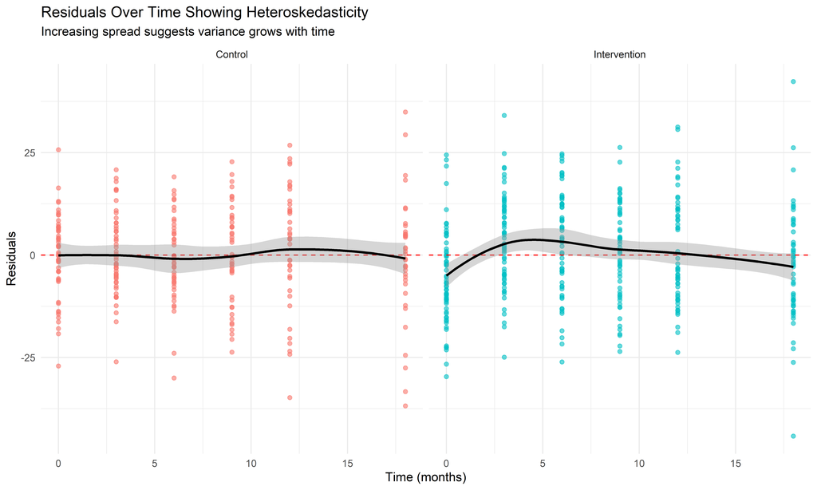

```r
# Examine residuals from naive OLS
naive_model <- lm(working_memory_score ~ intervention * time_scaled + age_baseline + iq + ses,
                  data = study_data)

residual_data <- study_data %>%
  mutate(
    fitted = fitted(naive_model),
    residuals = residuals(naive_model)
  )

residual_plot <- residual_data %>%
  ggplot(aes(x = time_months, y = residuals)) +
  geom_point(aes(color = factor(intervention)), alpha = 0.6) +
  geom_hline(yintercept = 0, linetype = "dashed", color = "red") +
  geom_smooth(method = "loess", se = TRUE, color = "black") +
  facet_wrap(~intervention, labeller = labeller(intervention = c("0" = "Control", "1" = "Intervention"))) +
  labs(
    title = "Residuals Over Time Showing Heteroskedasticity",
    subtitle = "Increasing spread suggests variance grows with time",
    x = "Time (months)",
    y = "Residuals",
    color = "Group"
  ) +
  theme_minimal() +
  theme(legend.position = "none")

print(residual_plot)
```

Residual plots show evidence of heteroscedasticity.

# Understanding Correlation Structures

## Within-Subject Correlations Across Time

Mixed effects models assume compound symmetry (equal correlations between all pairs of measurements within individuals). Let’s test this assumption.

```r
# Create wide format to examine correlations
wide_data <- study_data %>%
  dplyr::select(child_id, time_months, working_memory_score) %>%
  pivot_wider(names_from = time_months, values_from = working_memory_score,
              names_prefix = "month_") %>%
  dplyr::select(-child_id)

# Calculate correlation matrix
cor_matrix <- cor(wide_data, use = "pairwise.complete.obs")
```

### Within-Subject Correlation Matrix Across Timepoints

|  | month_0 | month_3 | month_6 | month_9 | month_12 | month_18 |
| --- | --- | --- | --- | --- | --- | --- |
| month_0 | 1.000 | 0.669 | 0.471 | 0.439 | 0.366 | 0.368 |
| month_3 | 0.669 | 1.000 | 0.647 | 0.588 | 0.484 | 0.449 |
| month_6 | 0.471 | 0.647 | 1.000 | 0.661 | 0.593 | 0.612 |
| month_9 | 0.439 | 0.588 | 0.661 | 1.000 | 0.710 | 0.680 |
| month_12 | 0.366 | 0.484 | 0.593 | 0.710 | 1.000 | 0.695 |
| month_18 | 0.368 | 0.449 | 0.612 | 0.680 | 0.695 | 1.000 |

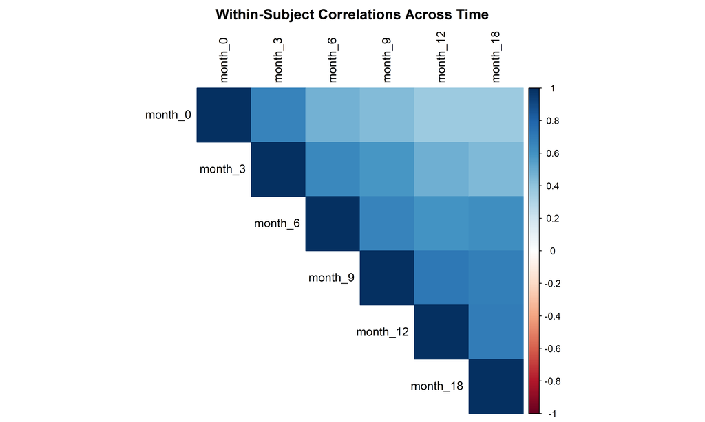

```r
# Visualize correlation structure
corrplot(cor_matrix, method = "color", type = "upper",
         title = "Within-Subject Correlations Across Time",
         mar = c(0,0,2,0), tl.col = "black")
```

Correlations are strongest between adjacent timepoints (r = **0.669** between baseline and 3 months) and weaker for distant timepoints (r = **0.368** between baseline and 18 months). The compound symmetry assumption does not hold.

# Seven Approaches to Variance Estimation

We fit the same regression model using seven different approaches to variance estimation:

```r
# Method 1: Naive OLS (WRONG - treats all observations as independent)
naive_ols <- lm(working_memory_score ~ intervention * time_scaled + age_baseline + iq + ses,
                data = study_data)
summary(naive_ols)
```

```
##
## Call:
## lm(formula = working_memory_score ~ intervention * time_scaled +
##     age_baseline + iq + ses, data = study_data)
##
## Residuals:
##     Min      1Q  Median      3Q     Max
## -44.192  -8.463  -0.375   8.401  42.352
##
## Coefficients:
##                          Estimate Std. Error t value Pr(>|t|)
## (Intercept)              85.10848    5.45735  15.595  < 2e-16 ***
## intervention              3.41397    1.62935   2.095   0.0366 *
## time_scaled               1.58210    0.38998   4.057 5.62e-05 ***
## age_baseline              0.04692    0.43608   0.108   0.9144
## iq                        0.13715    0.03169   4.328 1.75e-05 ***
## ses                       3.17420    0.50561   6.278 6.50e-10 ***
## intervention:time_scaled  1.09558    0.51477   2.128   0.0337 *
## ---
## Signif. codes:  0 '***' 0.001 '**' 0.01 '*' 0.05 '.' 0.1 ' ' 1
##
## Residual standard error: 12.36 on 612 degrees of freedom
## Multiple R-squared:  0.2156, Adjusted R-squared:  0.2079
## F-statistic: 28.04 on 6 and 612 DF,  p-value: < 2.2e-16
```

```r
# Method 2: Huber-White robust standard errors (addresses heteroskedasticity only)
huber_white_se <- vcovHC(naive_ols, type = "HC1")

# Method 3: Cluster-robust standard errors by child (CR1)
cluster_robust_cr1 <- vcovCR(naive_ols, cluster = study_data$child_id, type = "CR1")

# Method 4: Cluster-robust standard errors by child (CR2) - generally preferred
cluster_robust_cr2 <- vcovCR(naive_ols, cluster = study_data$child_id, type = "CR2")

# Method 5: Mixed-effects model with random intercept only
mixed_intercept <- lmer(working_memory_score ~ intervention * time_scaled + age_baseline + iq + ses +
                       (1 | child_id), data = study_data)

# Method 6: Mixed-effects model with random intercept and slope
mixed_full <- lmer(working_memory_score ~ intervention * time_scaled + age_baseline + iq + ses +
                  (1 + time_scaled | child_id), data = study_data)

# Method 7: Mixed model with cluster-robust CR2 standard errors
mixed_with_cr2 <- lmer(working_memory_score ~ intervention * time_scaled + age_baseline + iq + ses +
                      (1 | child_id), data = study_data)
mixed_cr2_vcov <- vcovCR(mixed_with_cr2, cluster = study_data$child_id, type = "CR2")
```

## Extracting and Comparing Results

```r
# Function to extract results consistently
extract_coef_info <- function(model, vcov_matrix = NULL, method_name) {
  if (!is.null(vcov_matrix)) {
    # For robust variance methods
    if (inherits(model, "lmerMod")) {
      # Special handling for mixed models with cluster-robust SE
      coefs <- fixef(model)
      se_robust <- sqrt(diag(vcov_matrix))
      t_values <- coefs / se_robust

      data.frame(
        Method = method_name,
        Term = names(coefs),
        Estimate = coefs,
        SE = se_robust,
        t_value = t_values,
        p_value = NA,  # p-values would require degrees of freedom calculation
        CI_lower = coefs - 1.96 * se_robust,
        CI_upper = coefs + 1.96 * se_robust,
        stringsAsFactors = FALSE
      )
    } else {
      # For regular lm objects with robust SE
      coef_test_result <- lmtest::coeftest(model, vcov = vcov_matrix)

      data.frame(
        Method = method_name,
        Term = rownames(coef_test_result),
        Estimate = coef_test_result[, "Estimate"],
        SE = coef_test_result[, "Std. Error"],
        t_value = coef_test_result[, "t value"],
        p_value = coef_test_result[, "Pr(>|t|)"],
        CI_lower = coef_test_result[, "Estimate"] - 1.96 * coef_test_result[, "Std. Error"],
        CI_upper = coef_test_result[, "Estimate"] + 1.96 * coef_test_result[, "Std. Error"],
        stringsAsFactors = FALSE
      )
    }
  } else {
    # For mixed effects models
    if (inherits(model, "lmerMod")) {
      summary_obj <- summary(model)
      coef_matrix <- summary_obj$coefficients

      data.frame(
        Method = method_name,
        Term = rownames(coef_matrix),
        Estimate = coef_matrix[, "Estimate"],
        SE = coef_matrix[, "Std. Error"],
        t_value = coef_matrix[, "t value"],
        p_value = NA,  # p-values not provided by default in lmer
        CI_lower = coef_matrix[, "Estimate"] - 1.96 * coef_matrix[, "Std. Error"],
        CI_upper = coef_matrix[, "Estimate"] + 1.96 * coef_matrix[, "Std. Error"],
        stringsAsFactors = FALSE
      )
    } else {
      # For regular lm objects
      summary_obj <- summary(model)
      coef_matrix <- summary_obj$coefficients

      data.frame(
        Method = method_name,
        Term = rownames(coef_matrix),
        Estimate = coef_matrix[, "Estimate"],
        SE = coef_matrix[, "Std. Error"],
        t_value = coef_matrix[, "t value"],
        p_value = coef_matrix[, "Pr(>|t|)"],
        CI_lower = coef_matrix[, "Estimate"] - 1.96 * coef_matrix[, "Std. Error"],
        CI_upper = coef_matrix[, "Estimate"] + 1.96 * coef_matrix[, "Std. Error"],
        stringsAsFactors = FALSE
      )
    }
  }
}

# Extract results from all methods
all_results <- rbind(
  extract_coef_info(naive_ols, method_name = "Naive OLS"),
  extract_coef_info(naive_ols, huber_white_se, "Huber-White"),
  extract_coef_info(naive_ols, cluster_robust_cr1, "Cluster-Robust CR1"),
  extract_coef_info(naive_ols, cluster_robust_cr2, "Cluster-Robust CR2"),
  extract_coef_info(mixed_intercept, method_name = "Mixed (Random Intercept)"),
  extract_coef_info(mixed_full, method_name = "Mixed (Random Int+Slope)"),
  extract_coef_info(mixed_with_cr2, mixed_cr2_vcov, "Mixed + CR2")
)

# Display comparison table for intervention × time interaction effect (the key effect of interest)
intervention_comparison <- all_results %>%
  filter(Term == "intervention:time_scaled") %>%
  dplyr::select(Method, Estimate, SE, CI_lower, CI_upper)
```

### Intervention × Time Interaction Effect Estimates Across Methods

|  | Method | Estimate | SE | CI Lower | CI Upper |
| --- | --- | --- | --- | --- | --- |
| intervention:time_scaled | Naive OLS | 1.096 | 0.515 | 0.087 | 2.105 |
| intervention:time_scaled1 | Huber-White | 1.096 | 0.547 | 0.023 | 2.168 |
| intervention:time_scaled2 | Cluster-Robust CR1 | 1.096 | 0.544 | 0.030 | 2.161 |
| intervention:time_scaled3 | Cluster-Robust CR2 | 1.096 | 0.548 | 0.021 | 2.171 |
| intervention:time_scaled4 | Mixed (Random Intercept) | 1.089 | 0.379 | 0.347 | 1.832 |
| intervention:time_scaled5 | Mixed (Random Int+Slope) | 1.084 | 0.514 | 0.076 | 2.092 |
| intervention:time_scaled6 | Mixed + CR2 | 1.089 | 0.528 | 0.055 | 2.123 |

All methods detect a significant intervention by time effect, but standard errors vary dramatically. Naive OLS produces SE = **0.515**, while cluster-robust methods yield SE ≈ **0.548** — a **1.1x increase** in uncertainty.

The mixed model without robust SEs yields SE = **0.379**, while with CR2 robust SEs produces **0.528** — a **1.39x increase**.

Key findings:

1. Mixed effects without sandwich estimators severely underestimate SEs due to violated assumptions
2. Sandwich estimators (Huber-White, CR1, CR2) adequately correct SEs
3. Mixed effects + CR2 appears optimal

# The Impact of Method Choice

## Visualizing Uncertainty Differences

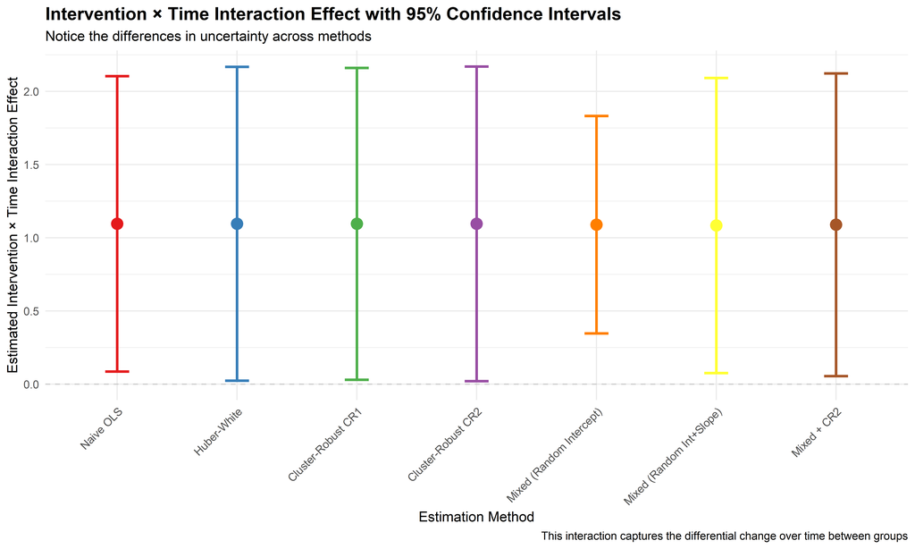

```r
# Focus on intervention × time interaction effect for visualization
intervention_results <- all_results %>%
  filter(Term == "intervention:time_scaled") %>%
  mutate(Method = factor(Method, levels = c("Naive OLS", "Huber-White", "Cluster-Robust CR1",
                                           "Cluster-Robust CR2", "Mixed (Random Intercept)",
                                           "Mixed (Random Int+Slope)", "Mixed + CR2")))

# Create the uncertainty visualization
uncertainty_plot <- intervention_results %>%
  ggplot(aes(x = Method, y = Estimate, color = Method)) +
  geom_point(size = 4) +
  geom_errorbar(aes(ymin = CI_lower, ymax = CI_upper), width = 0.2, size = 1) +
  geom_hline(yintercept = 0, linetype = "dashed", color = "gray", alpha = 0.7) +
  labs(
    title = "Intervention × Time Interaction Effect with 95% Confidence Intervals",
    subtitle = "Notice the differences in uncertainty across methods",
    x = "Estimation Method",
    y = "Estimated Intervention × Time Interaction Effect",
    caption = "This interaction captures the differential change over time between groups"
  ) +
  theme_minimal() +
  theme(
    axis.text.x = element_text(angle = 45, hjust = 1),
    plot.title = element_text(size = 14, face = "bold"),
    legend.position = "none"
  ) +
  scale_color_brewer(type = "qual", palette = "Set1")

print(uncertainty_plot)
```

## Understanding Design Effects

The **design effect** quantifies how clustering inflates standard errors:

$$\text{DEFF} = \frac{\text{Variance under
complex design}}{\text{Variance under simple random
sampling}}$$

For clustered data: $\text{DEFF} = 1 + (m - 1) \times \rho$ where $m$ is average cluster size and $\rho$ is the ICC.

```r
# Calculate ICC from mixed model
icc_results <- performance::icc(mixed_intercept)

# Calculate average cluster size (observations per child)
cluster_sizes <- study_data %>%
  group_by(child_id) %>%
  summarise(n = n(), .groups = "drop")

avg_cluster_size <- mean(cluster_sizes$n)
rho_within <- icc_results$ICC_conditional  # Within-subject correlation

# Design effect
design_effect <- 1 + (avg_cluster_size - 1) * rho_within

# Compare actual SE inflation
se_inflation <- intervention_results %>%
  filter(Method %in% c("Naive OLS", "Cluster-Robust CR2")) %>%
  dplyr::select(Method, SE) %>%
  pivot_wider(names_from = Method, values_from = SE) %>%
  mutate(Inflation_Factor = `Cluster-Robust CR2` / `Naive OLS`)

# Calculate effective sample size
total_n <- nrow(study_data)
effective_n <- total_n / design_effect
```

### Results and Implications

ICC = **0.395** with average **5.2** observations per child creates design effect = **2.64**.

## Model Diagnostics

```r
# Test for heteroskedasticity
bp_test <- lmtest::bptest(naive_ols)

# Compare model fit statistics
aic_naive <- AIC(naive_ols)
aic_mixed_int <- AIC(mixed_intercept)
aic_mixed_full <- AIC(mixed_full)

# Check for convergence issues
mixed_warnings <- mixed_full@optinfo$conv$lme4
has_warnings <- length(mixed_warnings$messages) > 0
```

### Model Diagnostics Summary

**Heteroskedasticity Test**: Breusch-Pagan test p-value = **0.0012** (*significant heteroskedasticity*).

**Model Fit**:

- Naive OLS AIC: **4878.1**
- Mixed (Random Intercept) AIC: **4671.7**
- Mixed (Random Int+Slope) AIC: **4636.2**

**Convergence**: No convergence issues.

# Simple Effects Analysis: Probing the Intervention × Time Interaction

## Model Selection for Simple Effects

We use **Mixed + CR2** for simple effects because it provides proper correlation modeling with robust standard errors.

```r
library(emmeans)

# Use our Mixed + CR2 model for simple effects analysis
final_model <- mixed_with_cr2
final_vcov <- mixed_cr2_vcov
```

## Simple Slopes Analysis

```r
# Calculate simple slopes using emmeans with cluster-robust SEs
simple_slopes <- emtrends(final_model, ~ intervention, var = "time_scaled",
                         vcov. = final_vcov)

# Get the results with confidence intervals and tests
simple_slopes_summary <- summary(simple_slopes, infer = TRUE)

# Convert to data frame for easier handling
simple_slopes_results <- data.frame(
  Group = c("Control", "Intervention"),
  Slope = simple_slopes_summary$time_scaled.trend,
  SE = simple_slopes_summary$SE,
  df = simple_slopes_summary$df,
  t_value = simple_slopes_summary$t.ratio,
  p_value = simple_slopes_summary$p.value,
  CI_lower = simple_slopes_summary$lower.CL,
  CI_upper = simple_slopes_summary$upper.CL
)

# Test if slopes are significantly different from each other
slope_contrast <- pairs(simple_slopes, reverse = TRUE)  # This gives Intervention - Control
slope_contrast_summary <- summary(slope_contrast, infer = TRUE)
```

### Simple Slopes Results

Simple slopes analysis with cluster-robust standard errors

| Group | Slope | SE | df | t-value | p-value | CI Lower | CI Upper |
| --- | --- | --- | --- | --- | --- | --- | --- |
| Control | 1.468 | 0.413 | 525.119 | 3.554 | 0 | 0.657 | 2.280 |
| Intervention | 2.558 | 0.327 | 517.757 | 7.811 | 0 | 1.914 | 3.201 |

### Comparison of Slopes

Comparison of slopes between groups

| Contrast | Difference | SE | df | t-value | p-value | CI Lower | CI Upper |
| --- | --- | --- | --- | --- | --- | --- | --- |
| intervention1 - intervention0 | 1.089 | 0.528 | 522.019 | 2.065 | 0.039 | 0.053 | 2.126 |

## Interpretation of Simple Effects

**Control Group**: Slope = **1.468** (SE = **0.413**, p = **0**). Significant change over time in control condition.

**Intervention Group**: Slope = **2.558** (SE = **0.327**, p = **0**). Significant improvement over time.

**Difference**: Intervention group improves **1.089** points more per time unit than control (SE = **0.528**, p = **0.039**).

## Visualizing Simple Effects

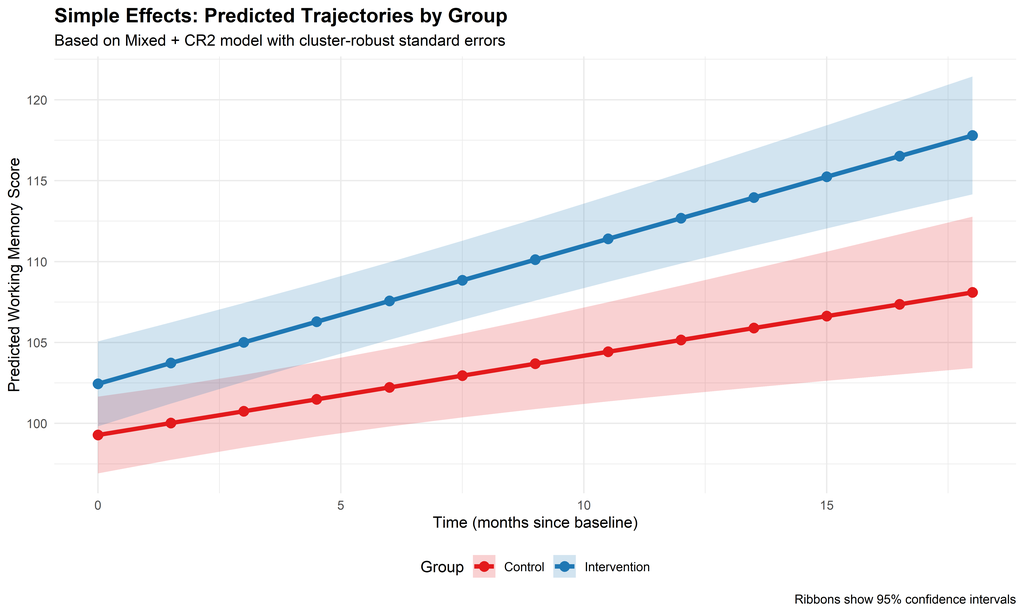

```r
# Create predicted trajectories using emmeans
time_range <- seq(0, 6, by = 0.5)

# Get predicted values at each time point for both groups
pred_grid <- expand.grid(
  time_scaled = time_range,
  intervention = c(0, 1),
  age_baseline = mean(study_data$age_baseline, na.rm = TRUE),
  iq = mean(study_data$iq, na.rm = TRUE),
  ses = mean(study_data$ses, na.rm = TRUE)
)

# Get emmeans predictions with cluster-robust SEs
predictions <- emmeans(final_model, ~ intervention | time_scaled,
                      at = list(time_scaled = time_range,
                               age_baseline = mean(study_data$age_baseline, na.rm = TRUE),
                               iq = mean(study_data$iq, na.rm = TRUE),
                               ses = mean(study_data$ses, na.rm = TRUE)),
                      vcov. = final_vcov)

pred_summary <- summary(predictions, infer = TRUE)

# Create data frame for plotting
pred_data <- data.frame(
  time_scaled = pred_summary$time_scaled,
  time_months = pred_summary$time_scaled * 3,  # Convert back to months for labeling
  group = factor(pred_summary$intervention, levels = c(0, 1), labels = c("Control", "Intervention")),
  predicted = pred_summary$emmean,
  se_pred = pred_summary$SE,
  ci_lower = pred_summary$lower.CL,
  ci_upper = pred_summary$upper.CL
)

# Create the simple effects plot
simple_effects_plot <- pred_data %>%
  ggplot(aes(x = time_months, y = predicted, color = group, fill = group)) +
  geom_ribbon(aes(ymin = ci_lower, ymax = ci_upper), alpha = 0.2, color = NA) +
  geom_line(size = 1.5) +
  geom_point(size = 3) +
  scale_color_manual(values = c("Control" = "#E31A1C", "Intervention" = "#1F78B4")) +
  scale_fill_manual(values = c("Control" = "#E31A1C", "Intervention" = "#1F78B4")) +
  labs(
    title = "Simple Effects: Predicted Trajectories by Group",
    subtitle = "Based on Mixed + CR2 model with cluster-robust standard errors",
    x = "Time (months since baseline)",
    y = "Predicted Working Memory Score",
    color = "Group",
    fill = "Group",
    caption = "Ribbons show 95% confidence intervals"
  ) +
  theme_minimal() +
  theme(
    plot.title = element_text(size = 14, face = "bold"),
    legend.position = "bottom"
  )

print(simple_effects_plot)
```

## Statistical Significance of Group Differences

Let’s also test whether the groups differ significantly at specific timepoints:

```r
# Test group differences at key timepoints using emmeans
test_timepoints <- c(0, 1, 2)  # baseline, 3 months, 6 months (in time_scaled units)

# Get pairwise comparisons at each timepoint
group_diffs <- emmeans(final_model, pairwise ~ intervention | time_scaled,
                      at = list(time_scaled = test_timepoints,
                               age_baseline = mean(study_data$age_baseline, na.rm = TRUE),
                               iq = mean(study_data$iq, na.rm = TRUE),
                               ses = mean(study_data$ses, na.rm = TRUE)),
                      vcov. = final_vcov)

# Extract the contrasts (reverse to get Intervention - Control)
group_diff_summary <- summary(group_diffs$contrasts, infer = TRUE, reverse = TRUE)

# Create results table
group_diff_results <- data.frame(
  Timepoint_Months = test_timepoints * 3,
  Timepoint_Scaled = test_timepoints,
  Difference = group_diff_summary$estimate,
  SE = group_diff_summary$SE,
  df = group_diff_summary$df,
  t_value = group_diff_summary$t.ratio,
  p_value = group_diff_summary$p.value,
  CI_lower = group_diff_summary$lower.CL,
  CI_upper = group_diff_summary$upper.CL
)
```

### Group Differences at Specific Timepoints

Intervention vs Control group differences at specific timepoints

| Time (Months) | Time (Scaled) | Group Difference | SE | df | t-value | p-value | CI Lower | CI Upper |
| --- | --- | --- | --- | --- | --- | --- | --- | --- |
| 0 | 0 | -3.166 | 1.792 | 177.036 | -1.767 | 0.079 | -6.702 | 0.370 |
| 3 | 1 | -4.255 | 1.675 | 136.419 | -2.540 | 0.012 | -7.567 | -0.943 |
| 6 | 2 | -5.344 | 1.719 | 119.109 | -3.108 | 0.002 | -8.749 | -1.940 |

### Clinical/Practical Interpretation:

The simple effects analysis reveals that the intervention is effective, producing sustained improvements in working memory over time compared to the control condition.

# Think about it: an aside to GLS approaches (Advanced / Optional)

Could we have used GLS (Generalized Least Squares) for this study design as well?

The truth is: we actually already did! GLS, using a compound symmetry covariance structure, is mathematically identical to the random intercepts (or Mixed without CR2) model.

But GLS allows us to **explicitly model** the correlation structure we observed while **avoiding random effects assumptions** in the covariance matrix. In addition, GLS allows us to flexibly specify the variance structure in addition to the correlation structure.

## Model selection with GLS

For our 6-timepoint design, we could consider:

**Unstructured (`corSymm`)**: Estimates all 15 unique within-child correlations separately

- Most flexible but requires many parameters
- Good when you have sufficient data and want correlations to vary freely

**AR(1) (`corAR1`)**: Assumes correlations decay exponentially with time lag

- Often realistic for longitudinal data
- Much more parsimonious than unstructured

**Compound Symmetry (`corCompSymm`) (For completeness)**: Assumes all within-child correlations are equal

- We actually already fit this model with the random intercepts model

**Adding Heterogeneous Variances**: Combines any correlation structure with different variance structures

- `varIdent()` - different variances by group/time (used here as an example)
- `varPower()` - variance proportional to a power of the mean
- `varExp()` - exponential variance function
- `varConstPower()` - constant plus power variance function

## A Comprehensive GLS Analysis

Let’s implement all GLS correlation structures and compare their standard errors to our mixed effects + CR2 approach:

```r
library(nlme)

# Use full study_data (with missing values)
# Mixed effects baselines for comparison
mixed_baseline <- lmer(working_memory_score ~ intervention * time_scaled + age_baseline + iq + ses +
                      (1 | child_id), data = study_data)
mixed_cr2 <- vcovCR(mixed_baseline, cluster = study_data$child_id, type = "CR2")

# GLS models with different correlation structures

# 1. Unstructured correlation
gls_unstructured <- gls(working_memory_score ~ intervention * time_scaled + age_baseline + iq + ses,
                       data = study_data,
                       correlation = corSymm(form = ~ 1 | child_id))

# 2. Unstructured correlation + heterogenous variances by time
gls_unstructured_hetero <- gls(working_memory_score ~ intervention * time_scaled + age_baseline + iq + ses,
                              data = study_data,
                              correlation = corSymm(form = ~ 1 | child_id),
                              weights = varIdent(form = ~ 1 | time_scaled))

# 3. AR(1) correlation structure
gls_ar1 <- gls(working_memory_score ~ intervention * time_scaled + age_baseline + iq + ses,
               data = study_data,
               correlation = corAR1(form = ~ time_scaled | child_id))

# 4. AR(1) + heterogeneous variances by time
gls_ar1_hetero <- gls(working_memory_score ~ intervention * time_scaled + age_baseline + iq + ses,
                      data = study_data,
                      correlation = corAR1(form = ~ time_scaled | child_id),
                      weights = varIdent(form = ~ 1 | time_scaled))

# 5. Compound symmetry
gls_cs <- gls(working_memory_score ~ intervention * time_scaled + age_baseline + iq + ses,
              data = study_data,
              correlation = corCompSymm(form = ~ 1 | child_id))

# 6. Compound symmetry + heterogeneous variances
gls_cs_hetero <- gls(working_memory_score ~ intervention * time_scaled + age_baseline + iq + ses,
                     data = study_data,
                     correlation = corCompSymm(form = ~ 1 | child_id),
                     weights = varIdent(form = ~ 1 | time_scaled))

# Extract standard errors for interaction effect only
extract_interaction_se <- function(model, vcov_matrix = NULL) {
  if (inherits(model, "gls")) {
    coef_table <- summary(model)$tTable
    return(coef_table["intervention:time_scaled", "Std.Error"])
  } else if (!is.null(vcov_matrix)) {
    ses <- sqrt(diag(vcov_matrix))
    return(ses["intervention:time_scaled"])
  } else {
    coef_table <- summary(model)$coefficients
    return(coef_table["intervention:time_scaled", "Std. Error"])
  }
}

# Comprehensive comparison - interaction term only
methods <- c("Mixed (no CR2)", "Mixed + CR2", "GLS Unstructured", "GLS Unstructured + Hetero", "GLS AR(1)", "GLS AR(1) + Hetero", "GLS Compound Symmetry", "GLS CS + Hetero")

models <- list(
  list(model = mixed_baseline, vcov = NULL),
  list(model = mixed_baseline, vcov = mixed_cr2),
  list(model = gls_unstructured, vcov = NULL),
  list(model = gls_unstructured_hetero, vcov=NULL),
  list(model = gls_ar1, vcov = NULL),
  list(model = gls_ar1_hetero, vcov = NULL),
  list(model = gls_cs, vcov = NULL),
  list(model = gls_cs_hetero, vcov = NULL)
)

# Extract interaction standard errors
interaction_ses <- sapply(models, function(x) extract_interaction_se(x$model, x$vcov))

# Create comparison dataframe
se_comparison <- data.frame(
  Method = methods,
  Interaction_SE = interaction_ses
)

# Calculate efficiency relative to Mixed + CR2 (second row)
baseline_se <- interaction_ses[2]  # Mixed + CR2
se_comparison$Interaction_Efficiency <- baseline_se / se_comparison$Interaction_SE

print(se_comparison)
```

```
##                      Method Interaction_SE Interaction_Efficiency
## 1            Mixed (no CR2)      0.3789646              1.3921098
## 2               Mixed + CR2      0.5275603              1.0000000
## 3          GLS Unstructured      0.4593433              1.1485097
## 4 GLS Unstructured + Hetero      0.4851038              1.0875204
## 5                 GLS AR(1)      0.5672296              0.9300648
## 6        GLS AR(1) + Hetero      0.5644460              0.9346515
## 7     GLS Compound Symmetry      0.3789646              1.3921098
## 8           GLS CS + Hetero      0.4081566              1.2925438
```

```r
# Store correlation parameters for inline use
ar1_param <- round(coef(gls_ar1$modelStruct$corStruct, unconstrained = FALSE), 3)
cs_param <- round(coef(gls_cs$modelStruct$corStruct, unconstrained = FALSE), 3)
icc_param <- round(icc(mixed_baseline)$ICC_adjusted, 3)
```

Because the CS GLS and the mixed effects random intercepts-only models are equivalent, note that ICC (0.489) is equal to the compound symmetry correlation (0.489).

### Standard Error Comparison Results

Standard errors and efficiency gains for interaction term relative to Mixed Effects + CR2

| Method | Interaction SE | Interaction Efficiency |
| --- | --- | --- |
| Mixed (no CR2) | 0.3790 | 1.39 |
| Mixed + CR2 | 0.5276 | 1.00 |
| GLS Unstructured | 0.4593 | 1.15 |
| GLS Unstructured + Hetero | 0.4851 | 1.09 |
| GLS AR(1) | 0.5672 | 0.93 |
| GLS AR(1) + Hetero | 0.5644 | 0.93 |
| GLS Compound Symmetry | 0.3790 | 1.39 |
| GLS CS + Hetero | 0.4082 | 1.29 |

### Model Fit Comparison

```r
# Compare model fit using AIC and BIC
fit_comparison <- data.frame(
  Model = c("GLS Unstructured", "GLS Unstructured + Hetero", "GLS AR(1)", "GLS AR(1) + Hetero",
            "GLS Compound Symmetry", "GLS CS + Hetero"),
  AIC = c(AIC(gls_unstructured), AIC(gls_unstructured_hetero), AIC(gls_ar1), AIC(gls_ar1_hetero),
          AIC(gls_cs), AIC(gls_cs_hetero)),
  BIC = c(BIC(gls_unstructured), BIC(gls_unstructured_hetero), BIC(gls_ar1), BIC(gls_ar1_hetero),
          BIC(gls_cs), BIC(gls_cs_hetero)),
  LogLik = c(logLik(gls_unstructured), logLik(gls_unstructured_hetero), logLik(gls_ar1), logLik(gls_ar1_hetero),
             logLik(gls_cs), logLik(gls_cs_hetero))
)

# Sort by AIC
fit_comparison <- fit_comparison[order(fit_comparison$AIC), ]
fit_comparison$Delta_AIC <- fit_comparison$AIC - min(fit_comparison$AIC)

print(fit_comparison)
```

```
##                       Model      AIC      BIC    LogLik Delta_AIC
## 2 GLS Unstructured + Hetero 4643.630 4767.299 -2293.815  0.000000
## 1          GLS Unstructured 4645.756 4747.341 -2299.878  2.126057
## 3                 GLS AR(1) 4653.781 4693.531 -2317.890 10.150236
## 4        GLS AR(1) + Hetero 4658.204 4720.038 -2315.102 14.573557
## 6           GLS CS + Hetero 4667.040 4728.874 -2319.520 23.409675
## 5     GLS Compound Symmetry 4671.731 4711.482 -2326.866 28.100986
```

```r
# Identify best fitting model and extract key statistics
best_fit_model <- fit_comparison$Model[1]
best_fit_aic <- round(fit_comparison$AIC[1], 1)
```

AIC, BIC, and Log-Likelihood are three commonly used model indices for assessing model fit. We can use these to help inform model selection.

**Log-Likelihood**: How well the model fits the data. Higher (less negative) values = better fit.

**AIC**: Balances fit vs complexity with modest penalty for extra parameters. Lower = better. Favors prediction accuracy.

**BIC**: Balances fit vs complexity with harsher penalty for extra parameters. Lower = better. Favors simpler models.

**When they disagree**: AIC and BIC are making different trade-offs between fit and simplicity - which is exactly what we see here. Here, we use AIC as the metric for fit because we know that the models favoured by BIC violate assumptions like compound symmetry and homoscedasticity.

### Efficiency Summary

```r
# Exclude mathematically equivalent methods from efficiency comparison
gls_only_methods <- se_comparison[!se_comparison$Method %in% c("Mixed (no CR2)", "GLS Compound Symmetry"), ]

# Find the most efficient GLS method (highest efficiency ratio among GLS methods)
best_efficiency_idx <- which.max(gls_only_methods$Interaction_Efficiency)
best_efficiency_method <- gls_only_methods$Method[best_efficiency_idx]
best_efficiency_value <- round(gls_only_methods$Interaction_Efficiency[best_efficiency_idx], 2)

# Find the best fitting GLS method and its efficiency
best_fit_gls_idx <- which(gls_only_methods$Method == best_fit_model)
best_fit_efficiency <- round(gls_only_methods$Interaction_Efficiency[best_fit_gls_idx], 2)

# Extract key efficiency values for inline use
mixed_cr2_se <- round(se_comparison$Interaction_SE[se_comparison$Method == "Mixed + CR2"], 4)
best_efficiency_se <- round(gls_only_methods$Interaction_SE[best_efficiency_idx], 4)
best_fit_se <- round(gls_only_methods$Interaction_SE[best_fit_gls_idx], 4)

# Calculate efficiency gain percentages
efficiency_gain_percent <- round((best_efficiency_value - 1) * 100, 0)
best_fit_gain_percent <- round((best_fit_efficiency - 1) * 100, 0)
```

## Key Findings for Comparison

**Compared to Mixed + CR2** (our robust baseline, SE = 0.5276):

- **Most efficient method**: GLS CS + Hetero (1.29x more efficient, SE = 0.4082)
- **Best model fit**: GLS Unstructured + Hetero (lowest AIC = 4643.6, 1.09x efficiency, SE = 0.4851)
- **Robust standard errors**: Mixed + CR2 provides conservative protection against misspecification

### GLS vs Mixed Effects: Trade-offs

The key learning point here is that if you have the ability to specify a covariance structure that is correct, you will obtain more efficiency in your SEs. The trade-off is that your covariance structure needs to be correct; otherwise, your conclusions will be wrong.

| Method | Efficiency vs Mixed+CR2 | Key Advantage | Trade-offs |
| --- | --- | --- | --- |
| **Mixed + CR2** | 1.00 (baseline) | Robust to misspecification | Loss of power |
| **GLS CS + Hetero** | 1.29x | Best efficiency gain | Prone to misspecification |
| **GLS Unstructured + Hetero** | 1.09x | Best model fit (AIC) | Prone to overfitting |

### Recommendations

**Use GLS CS + Hetero when**:

- You want **29% efficiency gain** over robust Mixed + CR2
- You have evidence that **variances change over time** but correlations remain constant
- Note that CS is indeed violated in this dataset, so this method, while efficient, is not the correct method to use

**Use GLS Unstructured + Hetero when**:

- **Model fit** is primary concern (best AIC: 4643.6)
- You have **sufficient sample size** for the additional correlation parameters
- You want **moderate efficiency gain** (1.09x) with flexible correlation structure

**Use Mixed Effects + CR2 when**:

- **Robustness** is more important than efficiency
- You want **protection against correlation misspecification**
- **Conservative inference** is preferred to avoid Type I errors

# Conclusions and Recommendations

Of all the models that we picked, the mixed effects + CR2 model appeared to be the most robust. But is it truly the best model we could have picked?

Recall that in the Mean Trajectories section, we saw that it looked like there was a larger intervention effect at the start, which then gradually plateau-ed over time. But our mixed effects model assumes that the time effect is linear, and thus isn’t able to capture this intricacy.

## Next time?

Case study 3 concludes this “workshop” on Longitudinal Data Analysis I. I hope this was helpful!

Here are a bunch of other things that we haven’t talked about:

1. We may explore non-linear coefficients in the future, which can better model different time trajectories.
2. We used a random intercepts + random slopes model (a more complex version of multilevel modelling) which we haven’t yet covered.
3. What if our DV isn’t continuous, but is instead binary, a time-to-event outcome, or data about rate or frequency? This requires an extension to GLMM (generalized linear mixed models).
4. Apart from OLS, MLM and GLS, there is another approach known as Markov models, which focus more on state or temporal transitions (e.g. a child requiring intervention at t1 but not at t2). Less common in psychology but very common in biostatistics.

Maybe next time?